# Tug1 KO vs WT (Adult)

- other heatmap labels (csHeatmap)
- cache gsea and overlap figure!!
- tracks
- should import litter info

# Design Overview

This file shows the wt-v-ko comparison for Tug1.

Cuff overview:

```
## CuffSet instance with:
##   2 samples
##   26754 genes
##   77524 isoforms
##   0 TSS
##   0 CDS
##   0 promoters
##   0 splicing
##   0 relCDS
```

# QC

## Dispersion

[output not shown]

## Cross-replicate variability (fpkmSCVplot)

Differences in CV 2 can result in lower numbers of differentially expressed genes due to a higher degree of variability between replicate fpkm estimates.

Genes:

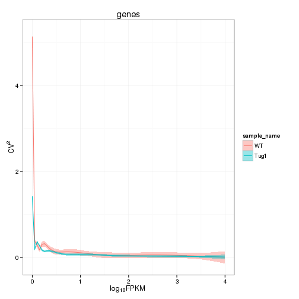

Isoforms:

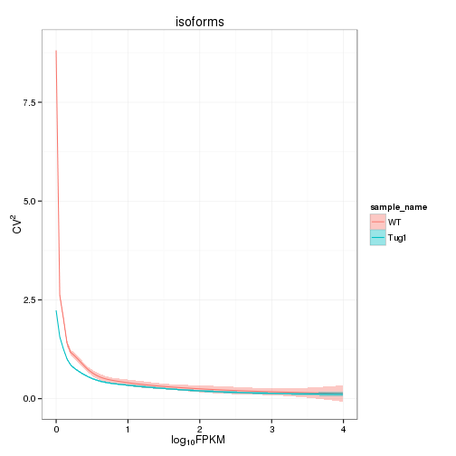

[output not shown]

### Volcano matrix (replicates)

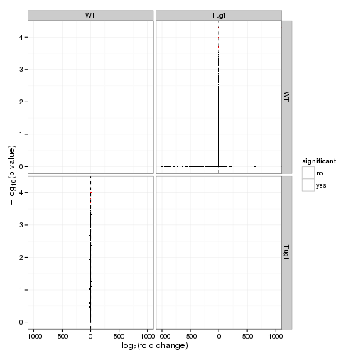

[output not shown]

[output not shown]

## Scatterplot

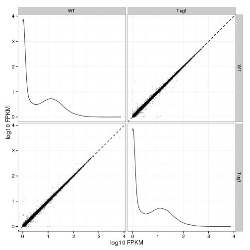

### Scatter matrix (replicates) – SKIP FOR NOW CAUSING PROBLEMS

## Distributions

### Boxplots

Boxplot (genes)

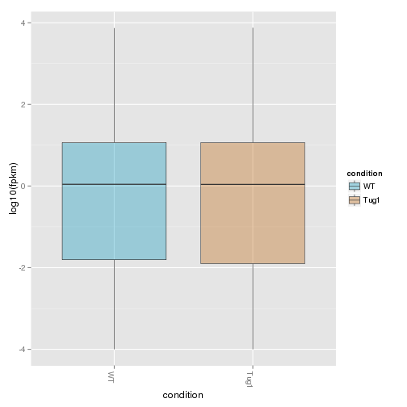

Boxplot (genes, replicates)

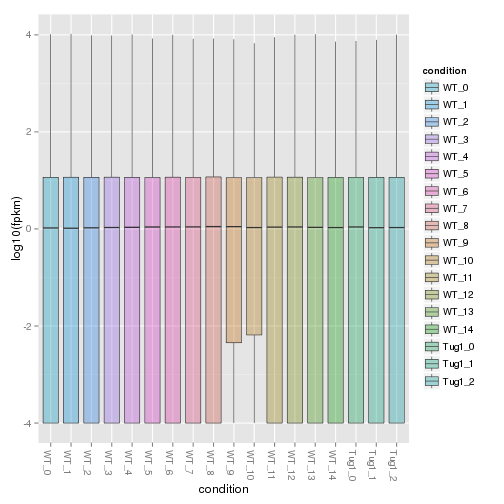

Boxplot (isoforms)

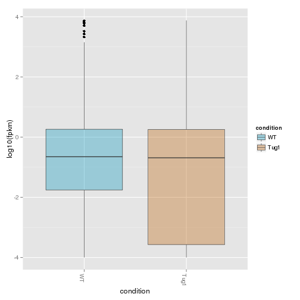

Boxplot (isoforms, replicates)

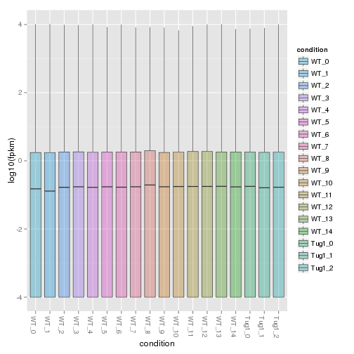

### Density

Density (genes)

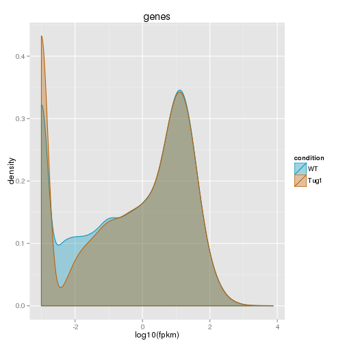

Density (genes, replicates)

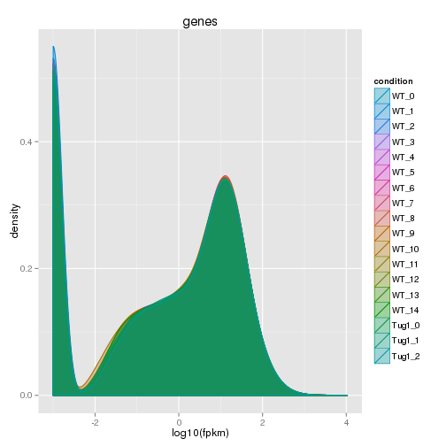

## Clustering

### Replicate Clusters

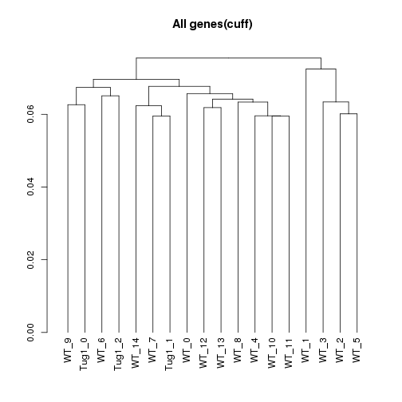

```
## 'dendrogram' with 2 branches and 18 members total, at height 0.07547
```

### PCA (genes)

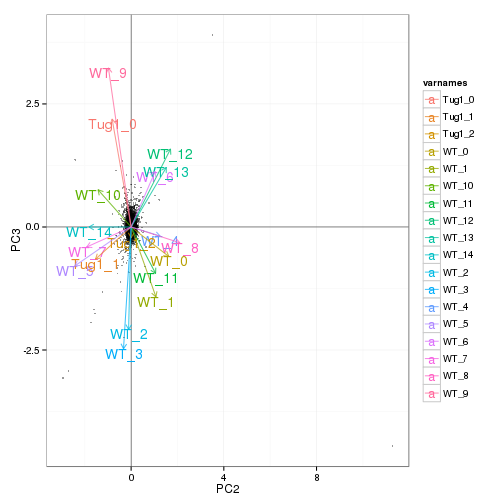

### MDS (genes)

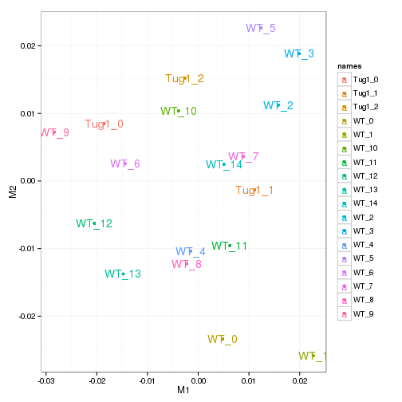

# KO assessment

## Endogenous lncRNA expression

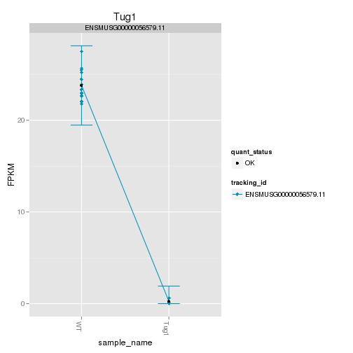

Endogenous expression of Tug1 isoforms:

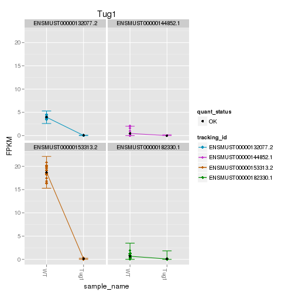

Barplot of gene expression:

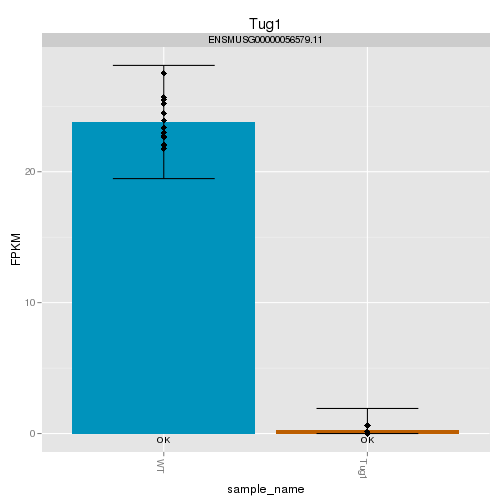

Barplot of isoform expression:

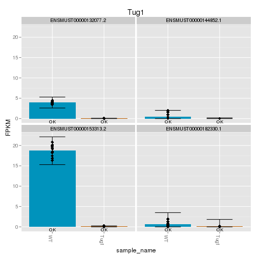

## LacZ expression

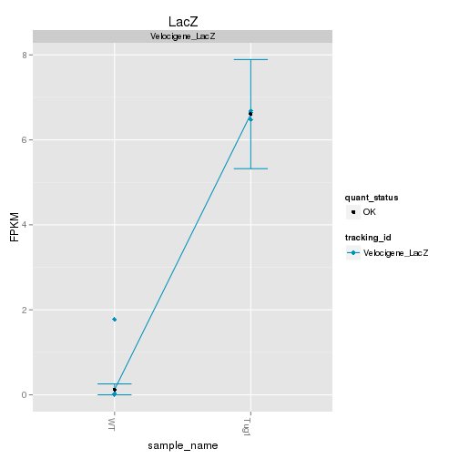

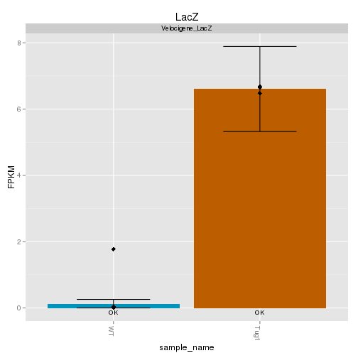

## Digital Genotyping (LacZ vs Endogenous lncRNA and Sex)

Expression plot (endogenous linc, lacZ, Y-expressed gene):

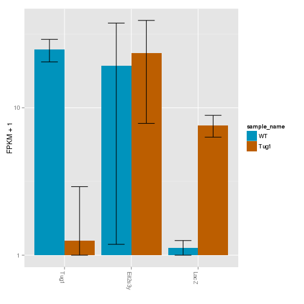

Expression heatmap:

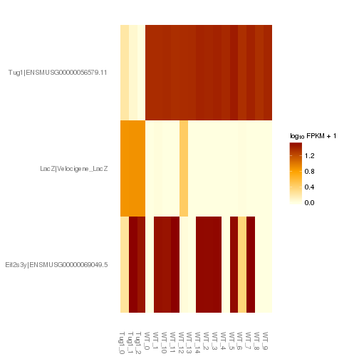

# Differential Analysis

## Differential Genes

There are 66 significantly differentially expressed genes. They are:

|  | geneAnnot$gene_short_name |
| --- | --- |
| 1 | Gabra2 |
| 2 | Ppp1r17 |
| 3 | Cd36 |
| 4 | Klf4 |
| 5 | Pde1c |
| 6 | Nes |
| 7 | Plxdc1 |
| 8 | 6330403K07Rik |
| 9 | Pdk4 |
| 10 | Gabra6 |
| 11 | Rnf185 |
| 12 | Adi1 |
| 13 | Serpina3n |
| 14 | Adamts1 |
| 15 | Glo1 |
| 16 | Esco1 |
| 17 | Cyp2e1 |
| 18 | Myoc |
| 19 | Car3 |
| 20 | Cyr61 |
| 21 | Padi2 |
| 22 | Ugt2a1 |
| 23 | Herc6 |
| 24 | Hddc3 |
| 25 | Dis3l |
| 26 | Ugt8a |
| 27 | Ndn |
| 28 | Arhgap27 |
| 29 | Morc2a |
| 30 | Inpp5j |
| 31 | Pla2g3 |
| 32 | 8430429K09Rik |
| 33 | Anln |
| 34 | Akap12 |
| 35 | Tspyl5 |
| 36 | Pcsk1n |
| 37 | Cbln3 |
| 38 | C1qtnf4 |
| 39 | Pyurf |
| 40 | 1700048O20Rik |
| 41 | Pcdhb14 |
| 42 | Nhlrc1 |
| 43 | Gm9493 |
| 44 | Rps2 |
| 45 | Acp1 |
| 46 | Npas4 |
| 47 | Fbll1 |
| 48 | Utp18 |
| 49 | Fat2 |
| 50 | S100a9 |
| 51 | Tug1 |
| 52 | Tpt1 |
| 53 | Cfd |
| 54 | Rpl17 |
| 55 | Rps4y2 |
| 56 | Ddx3y |
| 57 | Ppia |
| 58 | 3222401L13Rik |
| 59 | Selm |
| 60 | Gm14418 |
| 61 | Apold1 |
| 62 | Lrrc32 |
| 63 | AA465934 |
| 64 | Gm14403 |
| 65 | Gm26924 |
| 66 | LacZ |

### Matrix of gene significant differences between conditions

(skip for Brainmap wt-v-ko comparisons)

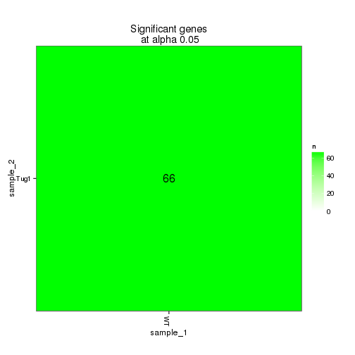

### Significant gene expression differences between conditions

Expression plot (genes):

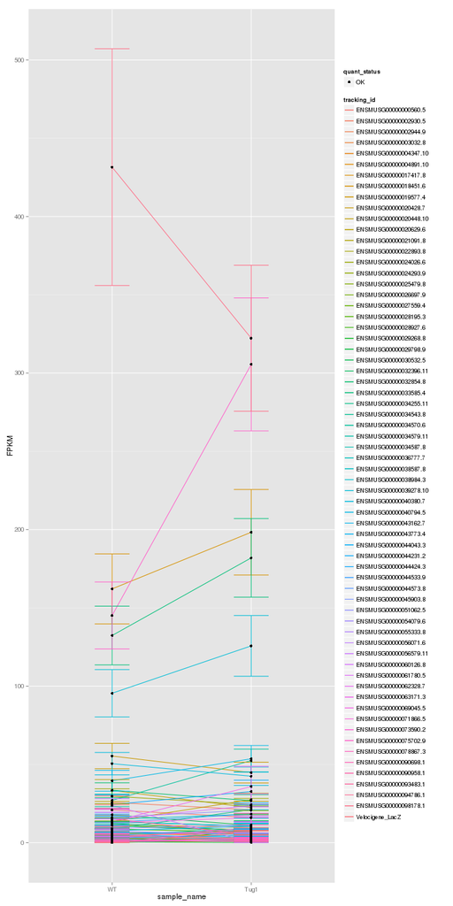

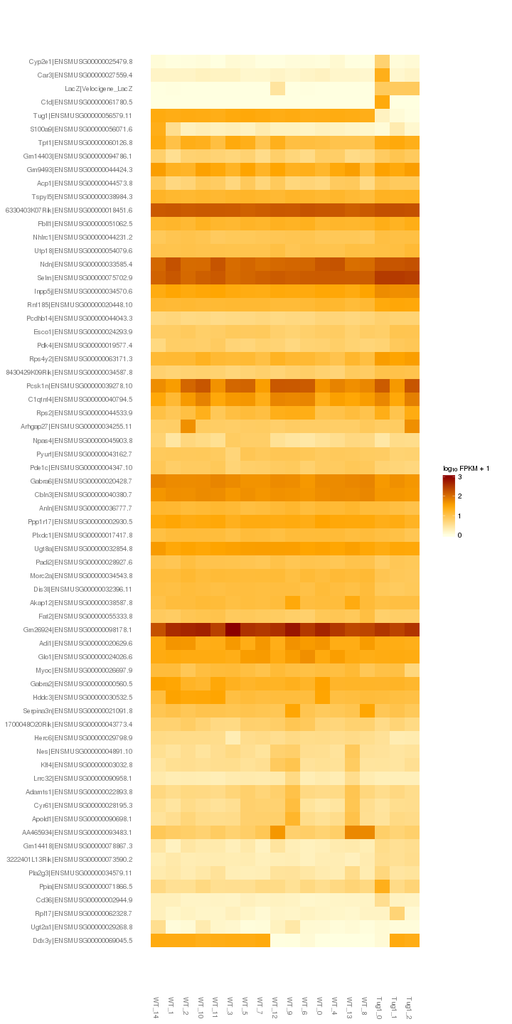

Significant genes with expression >50fpkm (any condition):

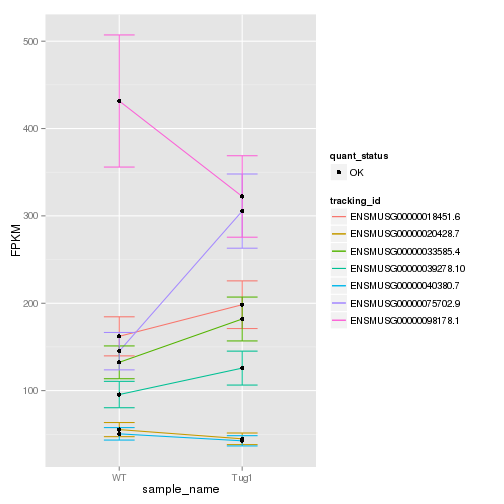

### Expression-level/significance relationship

[output not shown]

[output not shown]

## Differential Splicing

### Differential Isoforms between conditions

Per isoform difference between conditions:

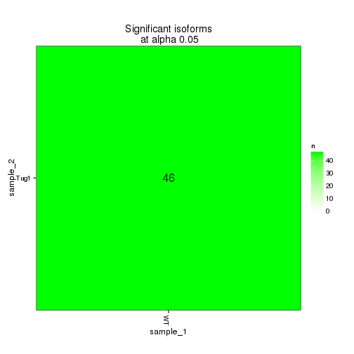

These isoforms are:

[output not shown]

[output not shown]

### Differential Splicing between conditions

(eval false for first pass)

Per condition differences in isoforms (Does gene have diff piechart between conditions?)

# Gene/Pathway Analysis

## GSEA

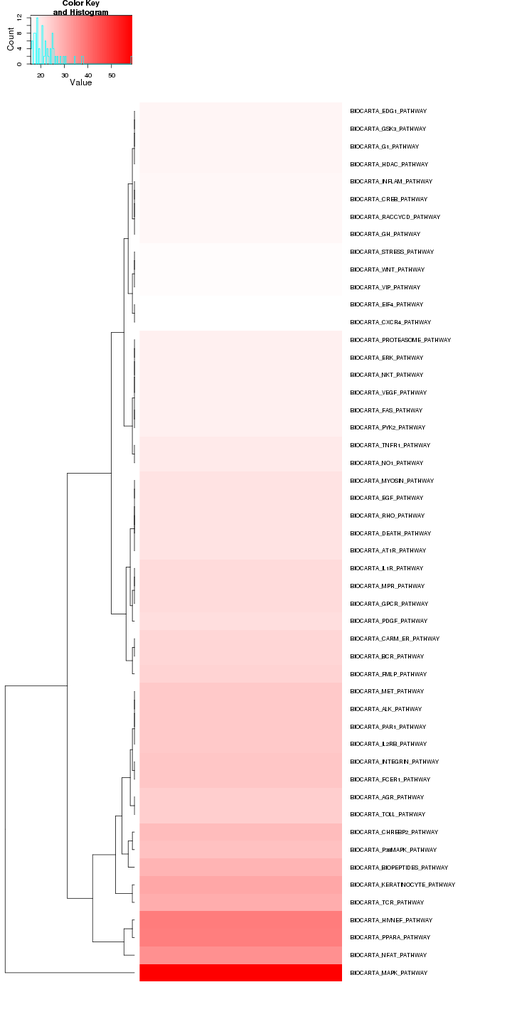

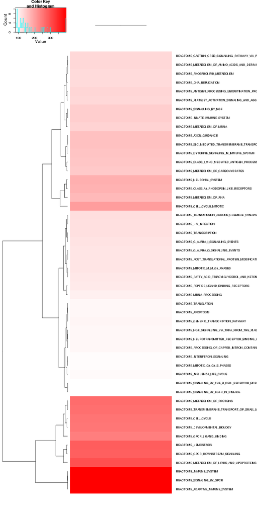